# Advanced EDA on World Health Statistics

Patrick Lim, Tan Kar Way

23 August, 2020

# 1 Install Packages

The package **ggplot2** is free and open source data visualization package for the statistical programming language R. It makes it simple to create complex plots from data in a data frame. It provides a more programmatic interface for specifying what variables to plot, how they are displayed, and general visual properties.

GGPlot2 is contained in the Tidyverse collection of R packages, which contains a collection of R packages designed for data science. Reference: https://www.tidyverse.org/

Install ggplot2 in console by using the command “install.packages(”ggplot2“)”

# 2 Load the Data File

Now let us read the data file using “read.csv” function. We have set the argument stringAsFactors to FALSE so that any string characters will be converted to character data type instead of staying as a factor, for the ‘Country’ and ‘Region’ column in this case.

```r
data = read.csv("cleaned_WHS_2019.csv", stringsAsFactors = FALSE)
str(data)
```

```
## 'data.frame':    194 obs. of  14 variables:
##  $ Country               : chr  "Afghanistan" "Albania" "Algeria" "Andorra" ...
##  $ Region                : chr  "Eastern Mediterranean" "Europe" "Africa" "Europe" ...
##  $ Male                  : int  18310 1479 20866 38 14605 49 21668 1378 12181 4283 ...
##  $ Female                : int  17220 1451 20452 39 15179 53 22603 1552 12270 4452 ...
##  $ Total_Pop             : int  35530 2930 41318 77 29784 102 44271 2930 24451 8735 ...
##  $ Life_Expectancy_Male  : num  61 74.3 75.4 NA 60.3 72.5 73.5 71.2 81 79.4 ...
##  $ Life_Expectancy_Female: num  64.5 78.6 77.4 NA 64.9 77.5 80.3 78.1 84.8 84.2 ...
##  $ Life_Expectancy_Both  : num  62.6 76.4 76.4 NA 62.6 75 76.9 74.8 82.9 81.8 ...
##  $ Health_Exp_Per_Capita : int  57 272 260 3835 3835 623 955 359 5002 4688 ...
##  $ Health_Expend_of_GDP  : num  10.2 6.7 6.6 10.4 2.9 4.3 7.5 9.9 9.3 10.4 ...
##  $ Child_Mortality_Rate  : num  3.9 0.6 1.5 0.1 2.9 0.4 0.6 0.7 0.2 0.2 ...
##  $ Heart_Disease_Male    : num  31.8 20.7 15.2 NA 17.2 25.2 19.7 30.9 11 14.4 ...
##  $ Heart_Disease_Female  : num  27.7 13.1 13.2 NA 16 20 12.2 15 7.2 8.5 ...
##  $ Heart_Disease_Total   : num  29.8 17 14.2 NA 16.5 22.6 15.8 22.3 9.1 11.4 ...
```

# 3 Advanced Plots using ggplot2 library

## 3.1 Bar chart

We will demonstrate how to plot a bar chart of “Total Population in Each Country”.

We will be using the “ggplot2” package to plot the bar charts so we need to install and load the “ggplot2” package first.

```r
library(ggplot2)
```

To prevent cluttering the chart, we are going to reduce to just 15 countries (15 countries with smallest population). First, we need to install and load the “dplyr” package for data manipulation.

```r
library(dplyr)
```

We order the data using the Total_Pop variable, then slice the data to the smallest 15 countries in terms of population. We keep the output of the data in data_15 data frame.

```r
data_15 <- data[order(data$Total_Pop), ] %>%
  slice(1:15)

# Print a few rows to have a look
head(data_15)
```

|  | Country | Region | Male | Female | Total_Pop | Life_Expectancy_Male | Life_Expectancy_Female | Life_Expectancy_Both | Health_Exp_Per_Capita | Health_Expend_of_GDP | Child_Mortality_Rate | Heart_Disease_Male | Heart_Disease_Female | Heart_Disease_Total |
| --- | --- | --- | --- | --- | --- | --- | --- | --- | --- | --- | --- | --- | --- | --- |
| 1 | Norway | Europe | 1 | 1 | 2 | NA | NA | NA | 1010 | 7.3 | 1.1 | NA | NA | NA |
| 2 | Nepal | SouthEast Asia | 6 | 6 | 11 | NA | NA | NA | 1012 | 11.1 | 2.1 | NA | NA | NA |
| 3 | Tuvalu | Western Pacific | 6 | 6 | 11 | NA | NA | NA | 507 | 15.5 | 1.6 | NA | NA | NA |
| 4 | Cook Islands | Western Pacific | 9 | 9 | 17 | NA | NA | NA | 576 | 3.4 | 0.4 | NA | NA | NA |
| 5 | Papua New Guinea | Western Pacific | 11 | 11 | 22 | NA | NA | NA | 1674 | 11.7 | 0.8 | NA | NA | NA |
| 6 | Saudi Arabia | Eastern Mediterranean | 16 | 17 | 33 | NA | NA | NA | 3013 | 6.4 | 0.1 | NA | NA | NA |

Plotting the barplot. We need at least three things to create a plot using ggplot—(1) data, (2) an aesthetic mapping of variables in the data frame to visual output, and (3) a geometric object. First, let us create the ‘ggplot’ object with the data and the aesthetic mapping.

As we are plotting the bar chart, we will use the geom_bar function.

By default, geom_bar uses stat=“bin” . This makes the height of each bar equal to the number of cases in each group, and it is incompatible with mapping values to the y aesthetic. If you want the heights of the bars to represent values in the data, use stat=“identity” and map a value to the y aesthetic (aes), in this case we map “data_15$Total_Pop”.

“Fill” is the colour of your bar charts, ‘steelblue’ is used in this case. See https://www.graphviz.org/doc/info/colors.html for more colors.

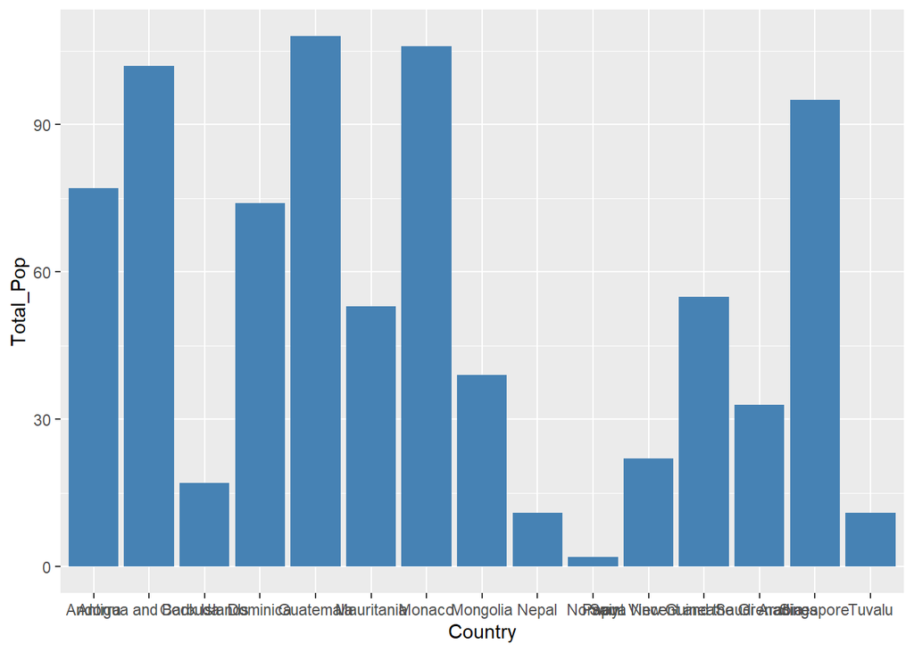

```r
# Basic barplot

p <-ggplot(data_15, aes(x=Country, y=Total_Pop)) +
  geom_bar(stat="identity", fill="steelblue")
p
```

Notice the labels on X-axis are too cluttered, we can slant the labels 45 degrees for better visibility using the theme function.

axis.text.x refers to the x axis which is the axis you are trying to modify. angle is the degree in which you want to slant your labels. hjust can take either value 0 (left-justified) or 1 (right-justified).

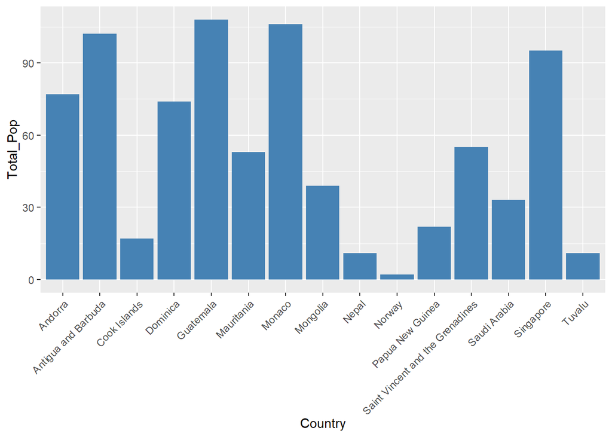

```r
p <- p + theme(axis.text.x = element_text(angle = 45, hjust = 1))
p
```

To label your population values on each bar, you can add *geom_text*. ‘label’ is the values that you are using to label your bars, ‘vjust’ is the position of your label and lastly, ‘size’ is the font size of your labels.

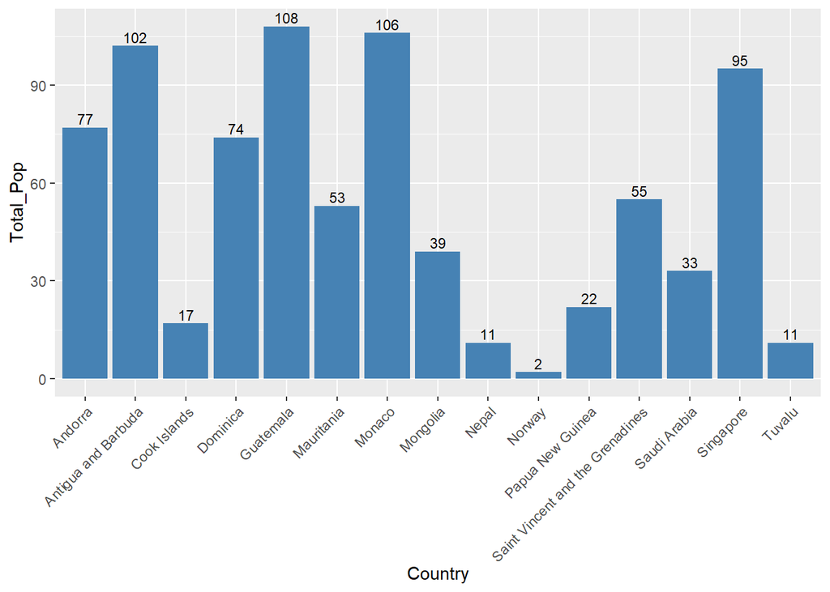

```r
p <- p + geom_text(aes(label= Total_Pop), vjust=-0.3, size=3)
p
```

If you would like to give better labels for both your axis, use the xlab and ylab functions.

To add a title, simply use the ggtitle function to add a meaningful title for your plot.

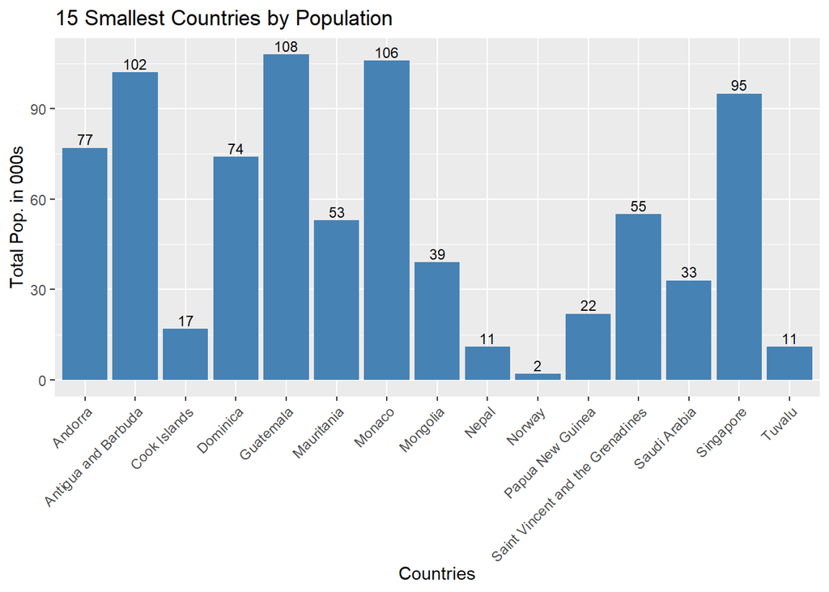

```r
p <- p + xlab("Countries") + ylab("Total Pop. in 000s") +
  ggtitle("15 Smallest Countries by Population")
p
```

Exercise: Now try plot a barchart for another variable.

## 3.2 Stacked Bar Chart

We will be demonstrating how to plot a stacked bar chart of “Total Male/Female Populaton in Each Country (Smallest 15 countries)”.

We will reuse the 15 smallest countries data we have sliced above. We will next build a data frame which contains all the countries and their respective number of males and females by combining the “Male” and “Female” columns using rbind.

We create another column lab_ypos to get a nice position for labeling our y values in the stacked bar chart.

```r
Countries <- data_15$Country

df_pop <- rbind(
        data.frame(Countries, "count" = data_15$Male, "gender"="Male"),
        data.frame(Countries, "count" = data_15$Female, "gender"="Female")
) %>%
  group_by(Countries) %>%
  mutate(lab_ypos = cumsum(count) - 0.5 * count)

df_pop
```

| Countries | count | gender | lab_ypos |
| --- | --- | --- | --- |
| Norway | 1 | Male | 0.5 |
| Nepal | 6 | Male | 3.0 |
| Tuvalu | 6 | Male | 3.0 |
| Cook Islands | 9 | Male | 4.5 |
| Papua New Guinea | 11 | Male | 5.5 |
| Saudi Arabia | 16 | Male | 8.0 |
| Mongolia | 19 | Male | 9.5 |
| Mauritania | 27 | Male | 13.5 |
| Saint Vincent and the Grenadines | 27 | Male | 13.5 |
| Dominica | 37 | Male | 18.5 |

[output cut: 20 more lines]

Now we can plot the stacked bar chart. Notice we split the bar chart by “fill = gender”. Also we use “identity” for geom_bar “stat” as we want the heights of the bars to represent values in the data.

We also use the precalculated postion “lab_ypos” to position our label at the center of each coloured bar.

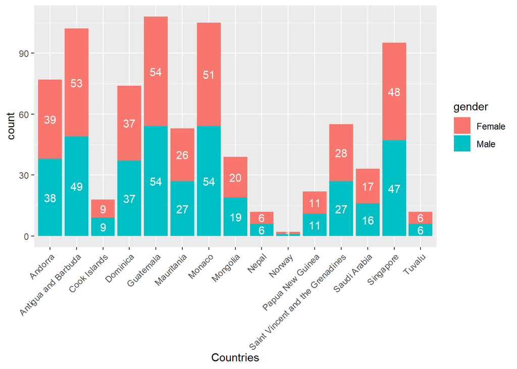

```r
ggplot(df_pop, aes(x= Countries, y=count, fill=gender)) +
    geom_bar(stat="identity") +
    geom_text(aes(y = lab_ypos, label = count), color = "white") +
    theme(axis.text.x = element_text(angle = 45, hjust = 1))
```

Exercise: Plot a stacked bar chart for another variable.

## 3.3 Line Chart

We will be demonstrating how to plot a line chart of “Life Expectancy vs. Health Expenditure Per Capita” belo using ggplot. Notice that instead of “geom_bar”, we use geom_line now.

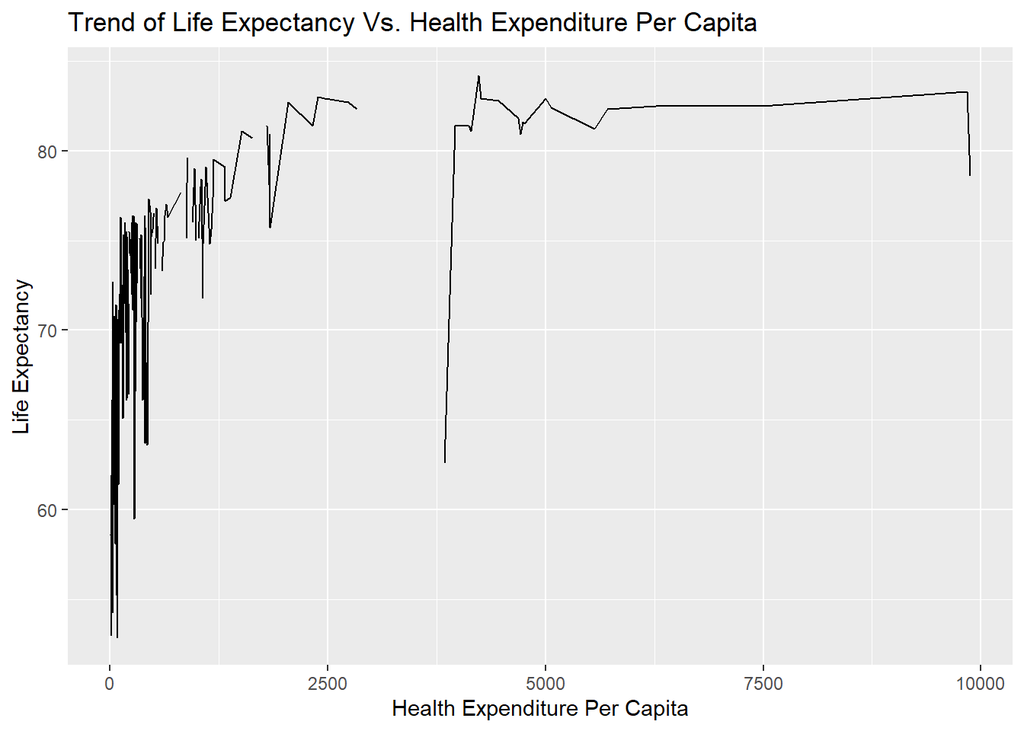

```r
ggplot(data=data, aes(x=Health_Exp_Per_Capita, y=Life_Expectancy_Both)) +
  geom_line() +
  xlab("Health Expenditure Per Capita") + ylab("Life Expectancy") +
  ggtitle("Trend of Life Expectancy Vs. Health Expenditure Per Capita")
```

Notice that the line chart is broken due to missing values, hence we will load the “tidyr” package which allows us to clean the missing values by dropping the observations with missing values.

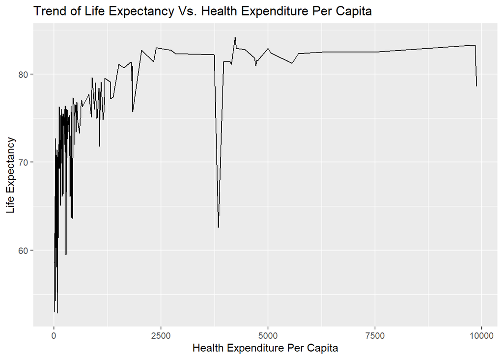

```r
library(tidyr)
data_clean <- data %>% drop_na(Life_Expectancy_Both, Health_Exp_Per_Capita)

ggplot(data=data_clean, aes(x=Health_Exp_Per_Capita, y=Life_Expectancy_Both, group=1)) +
  geom_line()+
  xlab("Health Expenditure Per Capita") + ylab("Life Expectancy") +
  ggtitle("Trend of Life Expectancy Vs. Health Expenditure Per Capita")
```

Exercise: Try plotting a line chart on another variable now.

## 3.4 Heatmap

Heatmap is useful if we have many variables that we want to compare. Think of it as a matrix table.

We will be demonstrating how to do a heatmap whereby we compare the number of males, number of females, life expectancy, heart disease proportion in each region.

As each row in the data represents a country’s statistics, we will do an aggregation of the data by regions first.

```r
data_agg <- data %>%
  group_by(Region) %>% summarise(Male = sum(Male), Female = sum(Female), Life_Expec = sum(Life_Expectancy_Both, na.rm= TRUE),
                                 Heart_Dis = sum(Heart_Disease_Total , na.rm= TRUE))
data_agg
```

| Region | Male | Female | Life_Expec | Heart_Dis |
| --- | --- | --- | --- | --- |
| Africa | 439369 | 447460 | 2900.8 | 882.8 |
| Americas | 614058 | 631097 | 2426.6 | 602.1 |
| Eastern Mediterranean | 392918 | 389107 | 1467.4 | 391.2 |
| Europe | 445787 | 450229 | 3762.2 | 978.7 |
| SouthEast Asia | 832321 | 782262 | 699.8 | 203.5 |
| Western Pacific | 1066110 | 1022598 | 1691.8 | 396.4 |

Next, we have to convert the dataframe into a matrix so that it can be converted to a heatmap later.

```r
matrix <- as.matrix(data_agg[, -1])
rownames(matrix) <- data_agg$Region
matrix
```

```
##                          Male  Female Life_Expec Heart_Dis
## Africa                 439369  447460     2900.8     882.8
## Americas               614058  631097     2426.6     602.1
## Eastern Mediterranean  392918  389107     1467.4     391.2
## Europe                 445787  450229     3762.2     978.7
## SouthEast Asia         832321  782262      699.8     203.5
## Western Pacific       1066110 1022598     1691.8     396.4
```

Now we can plot the heatmap with the matrix we created earlier.

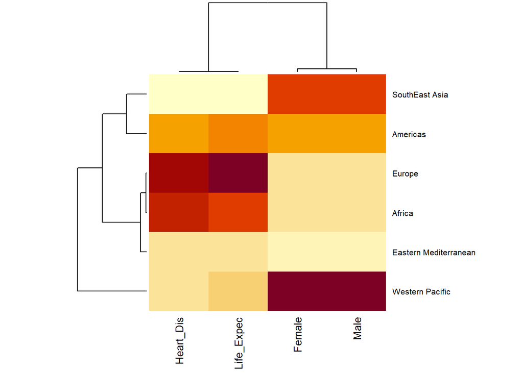

```r
heatmap(matrix, scale = "column", cexRow = 0.8, cexCol = 1)
```

Exercise: Try plotting a heatmap on other variables